PLACEMENT DATA ANALYSIS

```python
import pandas as pd
# Data loading, manipulation, and analysis.

import seaborn as sns
#Advanced and beautiful visualizations.

import numpy as np
#Numerical operations and array manipulations.

import matplotlib.pyplot as plt
#Plotting charts and customizing plots.

from statsmodels.stats.weightstats import ztest
#Performing Z-tests for hypothesis testing on means.

from scipy.stats import ttest_ind
#Performing independent T-tests to compare two groups.

from scipy.stats import chi2_contingency
#Performing Chi-square test of independence on categorical variables.

from scipy.stats import kruskal
#performing non-parametric alternative to one-way ANOVA

from sklearn.preprocessing import LabelEncoder
#Converting categorical text data to numeric labels.

from sklearn.preprocessing import StandardScaler
#fix the encoding columns in a region

from sklearn.model_selection import train_test_split
#Splitting dataset into training and testing sets for ML models.

from sklearn.linear_model import LinearRegression
#Performing linear regression to predict numerical values.

from scipy import stats
# Other statistical operations like correlation, normality tests, etc.

from scipy.stats import levene
```

# DATA LOADING

```python
data=pd.read_csv(r"C:\Users\NIHAL\Downloads\Placement_Data_Full_Class.csv")
data.head(10)
```

|  | sl_no | gender | ssc_p | ssc_b | hsc_p | hsc_b | hsc_s | degree_p | degree_t | workex | etest_p | specialisation | mba_p | status | salary |
| --- | --- | --- | --- | --- | --- | --- | --- | --- | --- | --- | --- | --- | --- | --- | --- |
| 0 | 1 | M | 67.00 | Others | 91.00 | Others | Commerce | 58.00 | Sci&Tech | No | 55.00 | Mkt&HR | 58.80 | Placed | 270000.0 |
| 1 | 2 | M | 79.33 | Central | 78.33 | Others | Science | 77.48 | Sci&Tech | Yes | 86.50 | Mkt&Fin | 66.28 | Placed | 200000.0 |
| 2 | 3 | M | 65.00 | Central | 68.00 | Central | Arts | 64.00 | Comm&Mgmt | No | 75.00 | Mkt&Fin | 57.80 | Placed | 250000.0 |
| 3 | 4 | M | 56.00 | Central | 52.00 | Central | Science | 52.00 | Sci&Tech | No | 66.00 | Mkt&HR | 59.43 | Not Placed | NaN |
| 4 | 5 | M | 85.80 | Central | 73.60 | Central | Commerce | 73.30 | Comm&Mgmt | No | 96.80 | Mkt&Fin | 55.50 | Placed | 425000.0 |
| 5 | 6 | M | 55.00 | Others | 49.80 | Others | Science | 67.25 | Sci&Tech | Yes | 55.00 | Mkt&Fin | 51.58 | Not Placed | NaN |
| 6 | 7 | F | 46.00 | Others | 49.20 | Others | Commerce | 79.00 | Comm&Mgmt | No | 74.28 | Mkt&Fin | 53.29 | Not Placed | NaN |
| 7 | 8 | M | 82.00 | Central | 64.00 | Central | Science | 66.00 | Sci&Tech | Yes | 67.00 | Mkt&Fin | 62.14 | Placed | 252000.0 |
| 8 | 9 | M | 73.00 | Central | 79.00 | Central | Commerce | 72.00 | Comm&Mgmt | No | 91.34 | Mkt&Fin | 61.29 | Placed | 231000.0 |
| 9 | 10 | M | 58.00 | Central | 70.00 | Central | Commerce | 61.00 | Comm&Mgmt | No | 54.00 | Mkt&Fin | 52.21 | Not Placed | NaN |

# COLUMN EXPLANATION

Column Name Description * sl_no Serial number (unique ID for each student record) * gender Gender of the student: M = Male, F = Female * ssc_p Secondary School Certificate (10th class) percentage * ssc_b Secondary school board: Central or Others * hsc_p Higher Secondary Certificate (12th class) percentage * hsc_b Higher secondary school board: Central or Others * hsc_s Specialization/Stream in higher secondary: Science, Commerce, or Arts * degree_p Degree (Undergraduate) percentage * degree_t Degree type: Sci&Tech (Science & Technology), Comm&Mgmt (Commerce & Management), or Others * workex Work experience before MBA: Yes or No * etest_p Employment test percentage (aptitude or assessment score) * specialisation MBA specialization: Mkt&Fin (Marketing & Finance) or Mkt&HR (Marketing & Human Resources) * mba_p MBA percentage score * status Placement status: Placed or Not Placed * salary Annual salary offered (only for placed students, in currency units)

# DATA CLEANING & PREPROCESSING:

```python
data.shape
```

```
(215, 15)
```

```python
data.size
```

```
3225
```

```python
data.columns
```

```
Index(['sl_no', 'gender', 'ssc_p', 'ssc_b', 'hsc_p', 'hsc_b', 'hsc_s',
       'degree_p', 'degree_t', 'workex', 'etest_p', 'specialisation', 'mba_p',
       'status', 'salary'],
      dtype='object')
```

```python
data.info()
```

```
<class 'pandas.core.frame.DataFrame'>
RangeIndex: 215 entries, 0 to 214
Data columns (total 15 columns):
 #   Column          Non-Null Count  Dtype
---  ------          --------------  -----
 0   sl_no           215 non-null    int64
 1   gender          215 non-null    object
 2   ssc_p           215 non-null    float64
 3   ssc_b           215 non-null    object
 4   hsc_p           215 non-null    float64
 5   hsc_b           215 non-null    object
 6   hsc_s           215 non-null    object
 7   degree_p        215 non-null    float64
 8   degree_t        215 non-null    object
 9   workex          215 non-null    object
 10  etest_p         215 non-null    float64
 11  specialisation  215 non-null    object
 12  mba_p           215 non-null    float64
 13  status          215 non-null    object
 14  salary          148 non-null    float64
dtypes: float64(6), int64(1), object(8)
memory usage: 25.3+ KB
```

```python
data.describe()
```

|  | sl_no | ssc_p | hsc_p | degree_p | etest_p | mba_p | salary |
| --- | --- | --- | --- | --- | --- | --- | --- |
| count | 215.000000 | 215.000000 | 215.000000 | 215.000000 | 215.000000 | 215.000000 | 148.000000 |
| mean | 108.000000 | 67.303395 | 66.333163 | 66.370186 | 72.100558 | 62.278186 | 288655.405405 |
| std | 62.209324 | 10.827205 | 10.897509 | 7.358743 | 13.275956 | 5.833385 | 93457.452420 |
| min | 1.000000 | 40.890000 | 37.000000 | 50.000000 | 50.000000 | 51.210000 | 200000.000000 |
| 25% | 54.500000 | 60.600000 | 60.900000 | 61.000000 | 60.000000 | 57.945000 | 240000.000000 |
| 50% | 108.000000 | 67.000000 | 65.000000 | 66.000000 | 71.000000 | 62.000000 | 265000.000000 |
| 75% | 161.500000 | 75.700000 | 73.000000 | 72.000000 | 83.500000 | 66.255000 | 300000.000000 |
| max | 215.000000 | 89.400000 | 97.700000 | 91.000000 | 98.000000 | 77.890000 | 940000.000000 |

```python
data.isna().sum()
```

```
sl_no              0
gender             0
ssc_p              0
ssc_b              0
hsc_p              0
hsc_b              0
hsc_s              0
degree_p           0
degree_t           0
workex             0
etest_p            0
specialisation     0
mba_p              0
status             0
salary            67
dtype: int64
```

```python
mean_salary = data['salary'].mean()
data['salary'].fillna(mean_salary, inplace=True)
```

```python
data.isna().sum()
```

```
sl_no             0
gender            0
ssc_p             0
ssc_b             0
hsc_p             0
hsc_b             0
hsc_s             0
degree_p          0
degree_t          0
workex            0
etest_p           0
specialisation    0
mba_p             0
status            0
salary            0
dtype: int64
```

```python
data.duplicated().sum
```

```
<bound method Series.sum of 0      False
1      False
2      False
3      False
4      False
       ...
210    False
211    False
212    False
213    False
214    False
Length: 215, dtype: bool>
```

```python
for i in data.columns:
    print(i)
    print(data[i].unique())
```

```
sl_no
[  1   2   3   4   5   6   7   8   9  10  11  12  13  14  15  16  17  18
  19  20  21  22  23  24  25  26  27  28  29  30  31  32  33  34  35  36
  37  38  39  40  41  42  43  44  45  46  47  48  49  50  51  52  53  54
  55  56  57  58  59  60  61  62  63  64  65  66  67  68  69  70  71  72
  73  74  75  76  77  78  79  80  81  82  83  84  85  86  87  88  89  90
  91  92  93  94  95  96  97  98  99 100 101 102 103 104 105 106 107 108
 109 110 111 112 113 114 115 116 117 118 119 120 121 122 123 124 125 126
 127 128 129 130 131 132 133 134 135 136 137 138 139 140 141 142 143 144
 145 146 147 148 149 150 151 152 153 154 155 156 157 158 159 160 161 162
 163 164 165 166 167 168 169 170 171 172 173 174 175 176 177 178 179 180
 181 182 183 184 185 186 187 188 189 190 191 192 193 194 195 196 197 198
 199 200 201 202 203 204 205 206 207 208 209 210 211 212 213 214 215]
gender
['M' 'F']
ssc_p
[67.   79.33 65.   56.   85.8  55.   46.   82.   73.   58.   69.6  47.
 77.   62.   63.   60.   79.   69.8  77.4  76.5  52.58 71.   76.76 64.
 61.   87.   69.   51.   81.   78.   74.   49.   76.   70.89 50.   75.2
 54.4  40.89 80.   60.4  68.   52.6  84.2  86.5  54.   83.   80.92 69.7
 75.   84.86 64.6  56.6  59.   66.5  84.   81.7  70.   83.84 59.6  66.
 85.   52.   60.23 70.5  45.   61.08 69.5  73.96 68.2  60.8  72.   80.4
 76.7  74.9  77.44 77.67 89.4  44.   75.4  53.   51.57 55.6  74.2  67.16
 63.3  67.9  48.   59.96 63.4  73.24 77.8  56.28 88.   78.5  61.8  65.2
 83.96 54.2  55.68 41.   83.33 43.   80.6 ]
ssc_b
['Others' 'Central']
hsc_p
[91.   78.33 68.   52.   73.6  49.8  49.2  64.   79.   70.   61.   68.4
 55.   87.   47.   75.   66.2  67.   66.   65.   76.   60.8  60.   97.7
 54.6  76.5  73.5  53.   81.   51.   78.   44.   58.   77.   63.16 39.
 73.   71.98 62.   37.   73.2  61.12 45.83 66.6  71.4  65.58 73.4  64.2
 74.   78.5  70.29 83.83 64.8  70.4  80.   90.9  63.   89.83 90.   57.
 69.   62.5  82.   72.   50.   54.   72.8  40.   66.8  59.   71.   89.7
 92.   56.   64.89 65.66 86.   58.66 60.5  74.66 69.4  49.   87.6  72.5
 42.16 67.2  50.83 97.   71.5  60.33 62.83 65.5  77.6  70.2  61.4  61.33
 42.  ]
hsc_b
['Others' 'Central']
hsc_s
```

[output cut: 45 more lines]

```
status
['Placed' 'Not Placed']
salary
[270000.         200000.         250000.         288655.40540541
 425000.         252000.         231000.         260000.
 218000.         300000.         236000.         265000.
 393000.         360000.         240000.         350000.
 278000.         320000.         411000.         287000.
 204000.         450000.         216000.         220000.
 268000.         275000.         336000.         230000.
 500000.         400000.         210000.         420000.
 380000.         280000.         276000.         940000.
 225000.         233000.         690000.         340000.
 255000.         285000.         290000.         650000.
 264000.         295000.        ]
```

```python
int=data.select_dtypes(include='int')
```

```python
int
```

|  | sl_no |
| --- | --- |
| 0 | 1 |
| 1 | 2 |
| 2 | 3 |
| 3 | 4 |
| 4 | 5 |
| ... | ... |
| 210 | 211 |
| 211 | 212 |
| 212 | 213 |
| 213 | 214 |
| 214 | 215 |

215 rows × 1 columns

# EDA(Exploratory Data Analysis)

## COUNT PLOT:

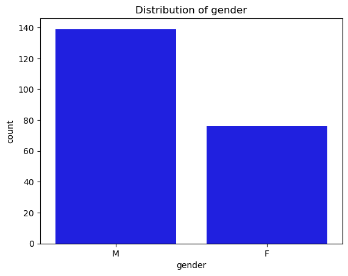

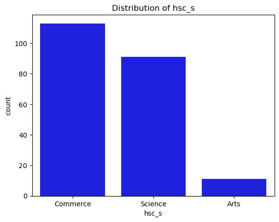

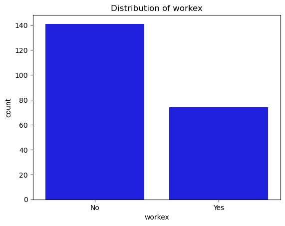

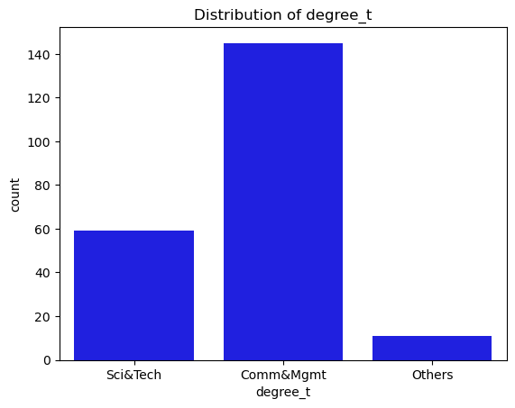

```python
categorical = ['gender', 'hsc_s', 'workex', 'degree_t']

for col in categorical:
    sns.countplot(x=col,color='blue', data=data)
    plt.title(f"Distribution of {col}")
    plt.show()
```

## HIST PLOT:

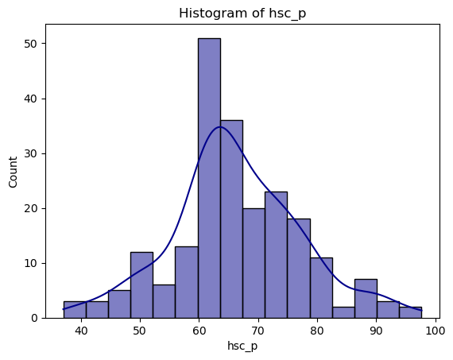

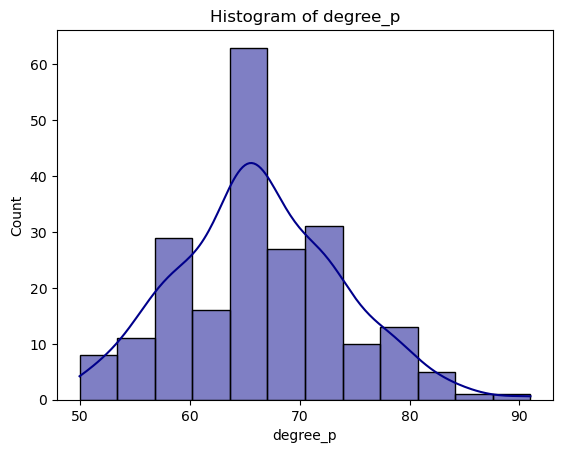

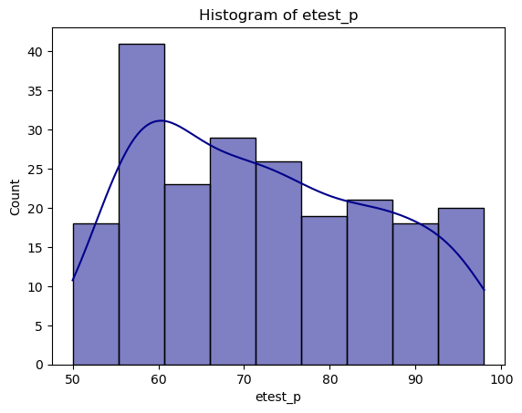

```python
numerical = ['hsc_p', 'degree_p', 'etest_p']

for col in numerical:
    sns.histplot(data[col], kde=True, color='darkblue')
    plt.title(f"Histogram of {col}")
    plt.show()
```

## BOX PLOT:

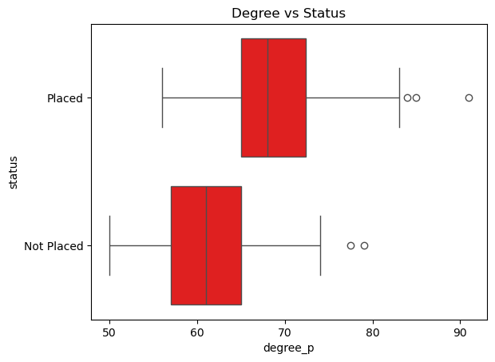

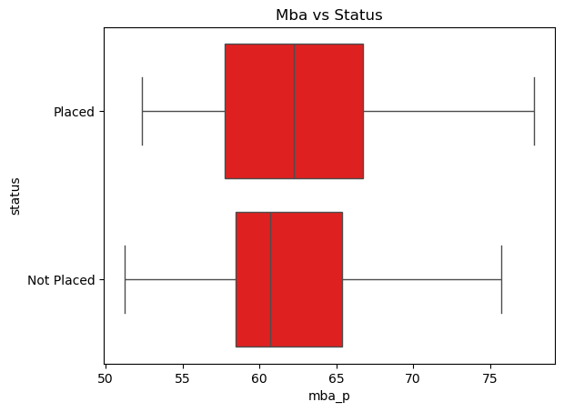

```python
sns.boxplot(x='degree_p', y='status',color='red', data=data)
plt.title("Degree vs Status")
plt.show()

sns.boxplot(x='mba_p', y='status',color='red', data=data)
plt.title("Mba vs Status")
plt.show()
```

## HEAT MAP:

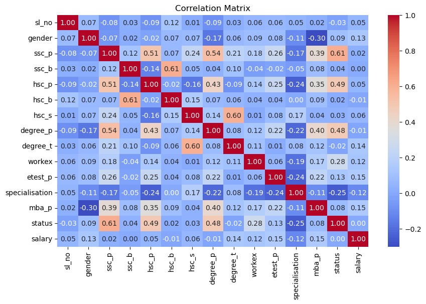

```python
from sklearn.preprocessing import LabelEncoder
df = data.copy()
for col in df.select_dtypes(include='object').columns:
    df[col] = LabelEncoder().fit_transform(df[col])

# Correlation heatmap
plt.figure(figsize=(10,6))
sns.heatmap(df.corr(), annot=True, cmap="coolwarm", fmt=".2f")
plt.title("Correlation Matrix")
plt.show()
```

## PAIR PLOT:

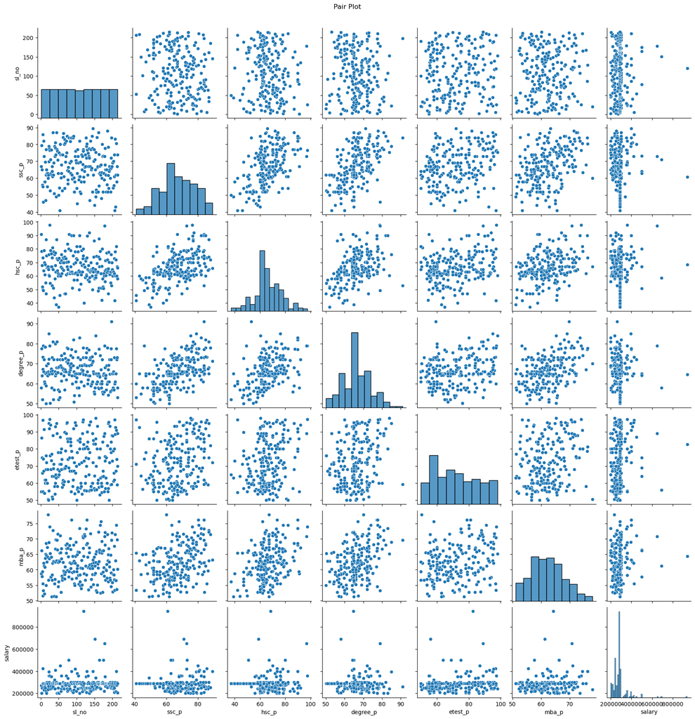

```python
sns.pairplot(data)
plt.suptitle("Pair Plot", y=1.02)
plt.show()
```

## BOX PLOT:

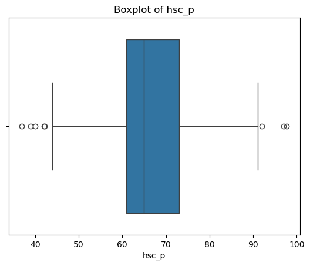

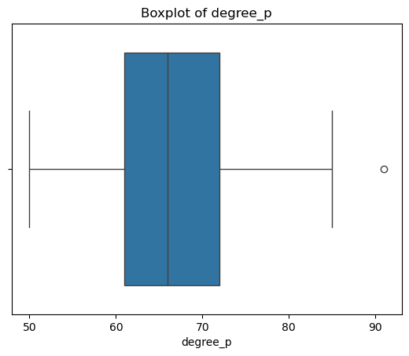

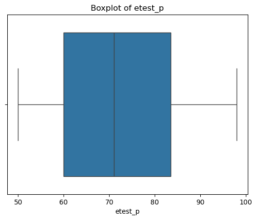

```python
for col in ['hsc_p', 'degree_p', 'etest_p']:
    sns.boxplot(x=data[col])
    plt.title(f"Boxplot of {col}")
    plt.show()
```

# Z-TEST:

- Null Hypothesis (H0):This is the default assumption that there is no difference between the population means or that the mean difference is zero.
- Alternative Hypothesis (H1):This is the assumption that there is a difference between the population means.

```python
z_stat,p_val=ztest(data['mba_p'],data['salary'],value=0)
```

```python
p_val
```

```
0.0
```

```python
if p_val<0.05:
    print("null hypothesis rejected")

else:
    print("null hypothesis accepted")
```

```
null hypothesis rejected
```

# T-TEST:

```python
t_stat, p_val1 = ttest_ind(data['etest_p'],data['salary'])
```

```python
p_val1
```

```
4.68261141345493e-195
```

```python
if p_val<0.05:
    print("null hypothesis rejected")

else:
    print("null hypothesis accepted")
```

```
null hypothesis rejected
```

# CHI SQUARE-TEST:

```python
categorical_cols = ['gender','status','hsc_s']
```

```python
 for col in categorical_cols:
    contingency_table = pd.crosstab(data[col], data['status'])
    chi2, p_val, dof, expected = chi2_contingency(contingency_table)

    print(f"Chi-square test between {col} and charges:")
    print(f"Chi2 Statistic: {chi2}")
    print(f"P-value: {p_val}")
    print(f"Degrees of Freedom: {dof}")
    print("Contingency Table:")
    print(contingency_table)
    print("\n")

    # Decision based on p-value
    if p_val < 0.05:
        print(f"There is a statistically significant association between {col} and status.")
    else:
        print(f"There is no statistically significant association between {col} and status.")
    print("\n")
```

```
Chi-square test between gender and charges:
Chi2 Statistic: 1.3817539668505108
P-value: 0.23980260881037566
Degrees of Freedom: 1
Contingency Table:
status  Not Placed  Placed
gender
F               28      48
M               39     100


There is no statistically significant association between gender and status.


Chi-square test between status and charges:
Chi2 Statistic: 210.36361074158467
P-value: 1.1442912259493803e-47
Degrees of Freedom: 1
Contingency Table:
status      Not Placed  Placed
status
Not Placed          67       0
Placed               0     148


There is a statistically significant association between status and status.


Chi-square test between hsc_s and charges:
Chi2 Statistic: 1.114745132708414
P-value: 0.5727118511343621
Degrees of Freedom: 2
Contingency Table:
status    Not Placed  Placed
hsc_s
Arts               5       6
Commerce          34      79
Science           28      63


There is no statistically significant association between hsc_s and status.
```

## ANOVA

```python
anova_data=data[['mba_p','salary']]
```

```python
groups=anova_data.groupby('mba_p')['salary'].apply(list)
groups
```

```
mba_p
51.21    [288655.4054054054]
51.29    [288655.4054054054]
51.45    [288655.4054054054]
51.58    [288655.4054054054]
52.21    [288655.4054054054]
                ...
74.56    [288655.4054054054]
75.71    [288655.4054054054]
76.18             [400000.0]
76.26             [400000.0]
77.89             [236000.0]
Name: salary, Length: 205, dtype: object
```

```python
f_statistic, p_value = stats.f_oneway(*groups)
```

```python
print(f"F-statistic: {f_statistic}")
print(f"P-value: {p_value}")
```

```
F-statistic: 4.2943267471198805
P-value: 0.007244865875792286
```

```python
if p_value < 0.05:
    print("There are significant differences between the groups.")
else:
    print("There are no significant differences between the groups.")
```

```
There are significant differences between the groups.
```

# F-TEST:

```python
data.shape
```

```
(215, 15)
```

```python
object = data.select_dtypes(include=['object']).columns
le = LabelEncoder()
for col in object:
    data[col] = le.fit_transform(data[col].astype(str))
print(data.head())
```

```
   sl_no  gender  ssc_p  ssc_b  hsc_p  hsc_b  hsc_s  degree_p  degree_t  \
0      1       1  67.00      1  91.00      1      1     58.00         2
1      2       1  79.33      0  78.33      1      2     77.48         2
2      3       1  65.00      0  68.00      0      0     64.00         0
3      4       1  56.00      0  52.00      0      2     52.00         2
4      5       1  85.80      0  73.60      0      1     73.30         0

   workex  etest_p  specialisation  mba_p  status         salary
0       0     55.0               1  58.80       1  270000.000000
1       1     86.5               0  66.28       1  200000.000000
2       0     75.0               0  57.80       1  250000.000000
3       0     66.0               1  59.43       0  288655.405405
4       0     96.8               0  55.50       1  425000.000000
```

```python
scaler = StandardScaler()
data['status'] = scaler.fit_transform(data[['status']])
print(data[['status']].head())
```

```
     status
0  0.672832
1  0.672832
2  0.672832
3 -1.486255
4  0.672832
```

```python
x = data.drop('status', axis=1)
y = data['status']
```

```python
x_train, x_test, y_train, y_test = train_test_split(x, y, test_size=0.3, random_state=42)
```

```python
model = LinearRegression()
model.fit(x_train, y_train)
```

```
LinearRegression()
```

```python
y_pred = model.predict(x_test)
```

```python
n = len(y_test)
p = x_train.shape[1]
```

```python
n
```

```
65
```

```python
p
```

```
14
```

```python
RSS = np.sum((y_test-y_pred)**2)
```

```python
TSS = np.sum((y_test-np.mean(y_test))**2)
```

```python
ESS = TSS-RSS
```

```python
MSE = RSS/(n-p-1)
```

```python
MSR = ESS/p
```

```python
F_statistics = MSR/MSE
```

```python
p_value = 1-stats.f.cdf(F_statistics,p,n-p-1)
```

```python
print('F-statistic:', F_statistics)
print('p-value:', p_value)
```

```
F-statistic: 2.9885357190847377
p-value: 0.0022222285136893616
```

```python
if p_value < 0.05:
    print("null hypothesis rejected")
else:
    print("null hypothesis accepted")
```

```
null hypothesis rejected
```

# Levene's Test:

```python
male_scores = df[df["gender"] == "M"]["mba_p"]
female_scores = df[df["gender"] == "F"]["mba_p"]
```

```python
# Example 1
stat_gender, p_gender = levene(male_scores, female_scores)
print("Levene’s Test (MBA % by Gender):")
print("Statistic =", stat_gender, ", p-value =", p_gender)
if p_gender > 0.05:
    print("✅ Variances are equal (homogeneity assumed).")
else:
    print("❌ Variances are not equal (heterogeneity detected).")
```

```
Levene’s Test (MBA % by Gender):
Statistic = nan , p-value = nan
❌ Variances are not equal (heterogeneity detected).
```

```python
# Example 2: Levene’s Test for Degree percentage (degree_p) across Specializations
group1 = df[df["specialisation"] == "Mkt&HR"]["degree_p"]
group2 = df[df["specialisation"] == "Mkt&Fin"]["degree_p"]

stat_spec, p_spec = levene(group1, group2)
print("\nLevene’s Test (Degree % by Specialisation):")
print("Statistic =", stat_spec, ", p-value =", p_spec)
if p_spec > 0.05:
    print("✅ Variances are equal.")
else:
    print("❌ Variances are not equal.")
```

```
Levene’s Test (Degree % by Specialisation):
Statistic = nan , p-value = nan
❌ Variances are not equal.
```